# State MSM Profile: **Missouri**

### Background & Methods

In 2015-2016, researchers at Emory University partnered with colleagues at the Centers for Disease Control and Prevention (CDC) to develop methods to estimate the number of men who have sex with men (MSM) residing in each county in the United States. Using population and housing data from the [American Community Survey](https://www.census.gov/programs-surveys/acs/) and estimates from two peer-reviewed publications ([Oster et al., 2015](http://www.ncbi.nlm.nih.gov/pubmed/26115985) & [Purcell et al., 2012](http://www.ncbi.nlm.nih.gov/pubmed/23049658)), they derived an indirect estimate of MSM population sizes that took into account both the urbanicity of the county as well as its density of households with a male householder and a male same-sex partner.

The full methodology is published in the *Journal of Medical Internet Research - Public Health and Surveillance*:

> [Grey JA, Bernstein KT, Sullivan PS, Purcell DW, Chesson HW, Gift TL, Rosenberg ES. Estimating the population sizes of men who have sex with men in US states and counties using data from the American Community Survey. JMIR Public Health Surveill 2016;2(1):e14. DOI: 10.2196/publichealth.5365](http://publichealth.jmir.org/2016/1/e14/)

### Overview of MSM in Missouri

An estimated **70,783** men who have sex with men (MSM) resided in Missouri in 2013, representing 1.6% of the 4,503,084 MSM in the United States. Of the 2,219,565 adult men of Missouri, 3.2% had had sex with another man in the past 5 years, which was less than the overall percentage of adult men in the United States who were MSM (3.9%).

Most MSM in Missouri resided in central counties of large metropolitan areas (37.6%). Including both central and fringe counties, 73.5% resided in a large metropolitan area.

##### **Percentage of MSM by urbanicity, United States and Missouri, 2013**

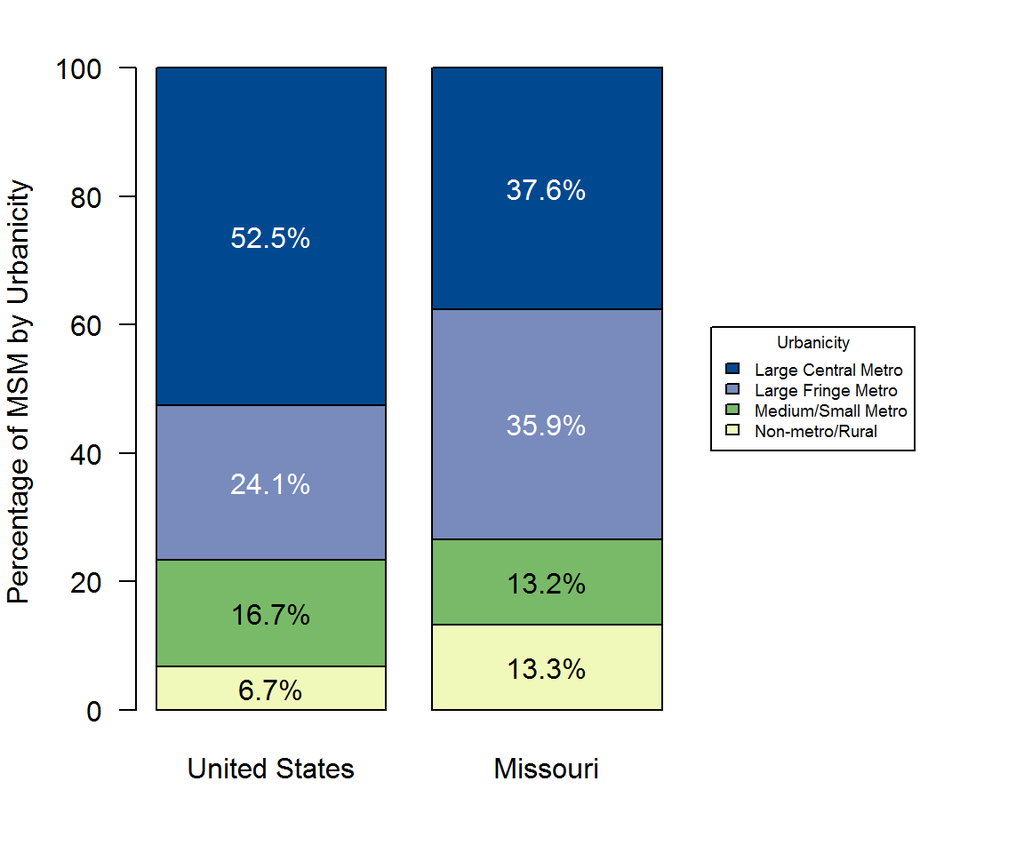

### MSM in Missouri Counties

Among counties or county-equivalent areas in Missouri, Jackson County had the largest population of MSM at 16,368, representing 23.1% of all MSM in the state. St. Louis city had the highest percentage of MSM among adult men in Missouri at 8.5%. This was greater than the percentage for Missouri as a whole, which was 3.2% of adult men.

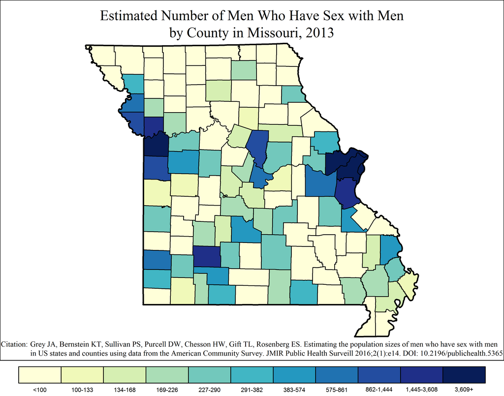

Note: Range cutpoints for the map are based on the distribution of MSM among all counties in the United States.

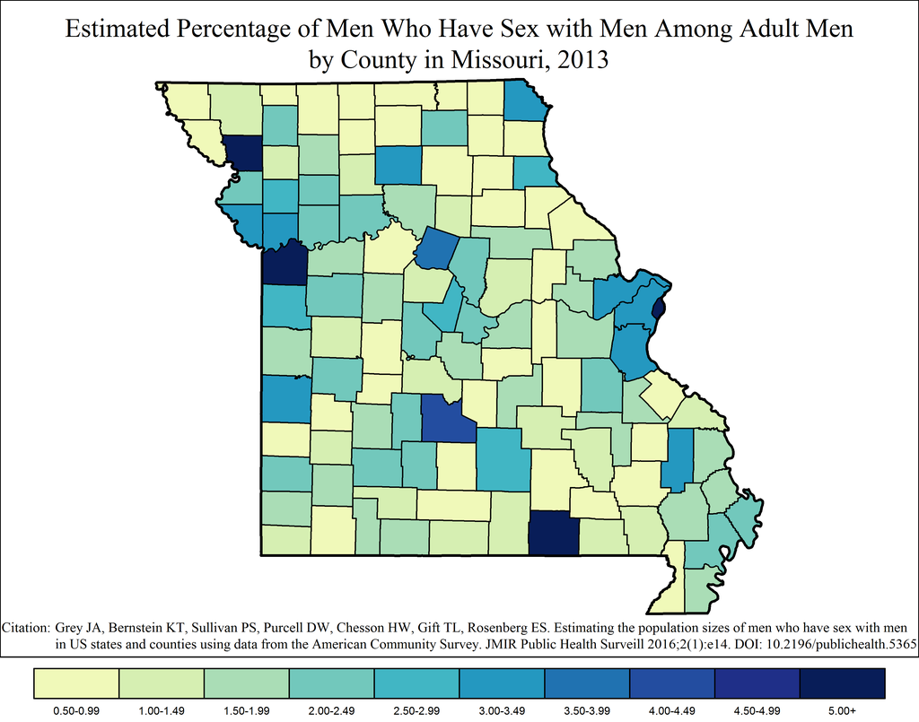

### MSM in Missouri Metropolitan Statistical Areas

#### St. Louis Metropolitan Statistical Area

The St. Louis MSA overlaps two states: Illinois and Missouri. The Missouri portion of the MSA had the largest metropolitan population of MSM in Missouri at 30,236, or 42.7% of all MSM in the state and 79.1% of the 38,221 MSM in the MSA. Of the 757,578 adult men in the Missouri part of St. Louis, an estimated 4.0% were MSM. This was greater than the percentage of MSM among adult men in the MSA as a whole, which was 3.8% of adult men (38,221 out of 1,015,361).

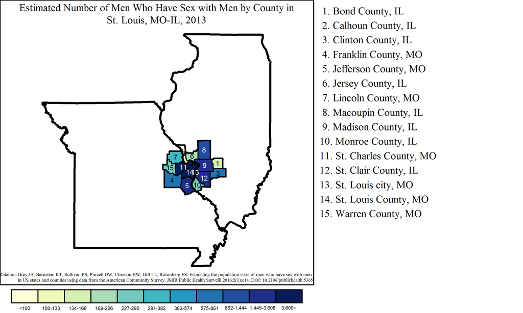

Note: Range cutpoints for the map are based on the distribution of MSM among all counties in the United States.

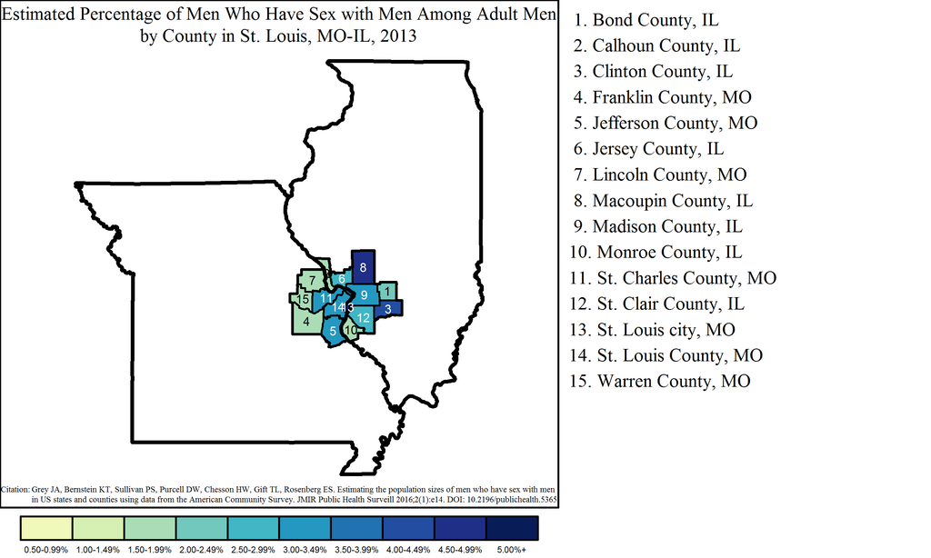

#### Kansas City Metropolitan Statistical Area

The Kansas City MSA overlaps two states: Kansas and Missouri. The Missouri portion of the MSA had 21,781 MSM, or 30.8% of all MSM in the state and 66.7% of the 32,669 MSM in the MSA. Of 430,853 adult men in the Missouri part of Kansas City, 5.1% were MSM. This was greater than the overall percentage of MSM among adult men in the MSA, which was 4.5% of adult men (32,669 out of 729,380).

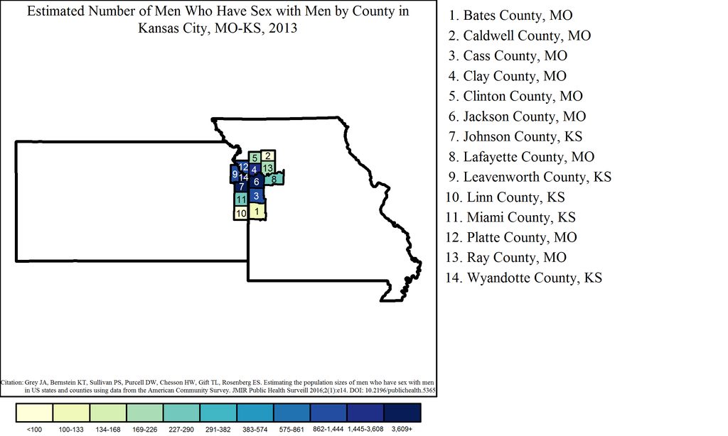

Note: Range cutpoints for the map are based on the distribution of MSM among all counties in the United States.

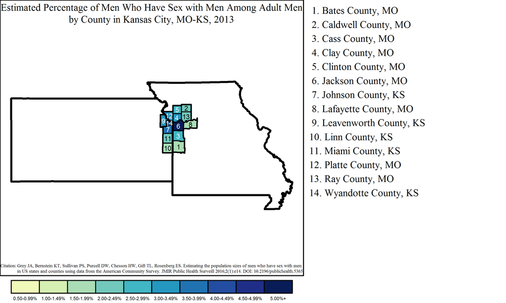

#### Springfield Metropolitan Statistical Area

The Springfield MSA had a population of 3,604 MSM, or 5.1% of all MSM in Missouri. Of the 163,804 adult men in Springfield, an estimated 2.2% were MSM.

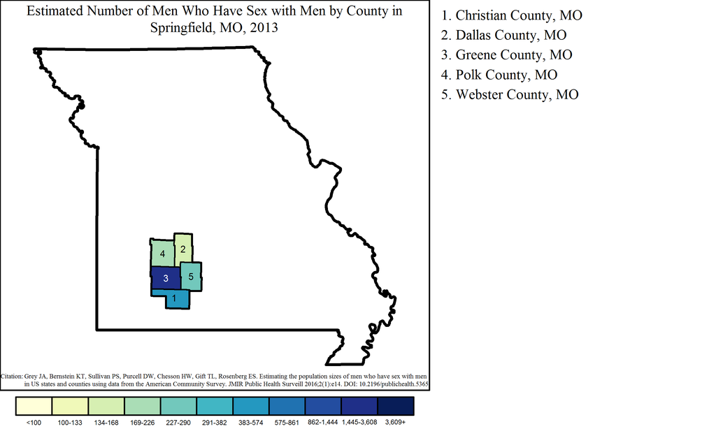

Note: Range cutpoints for the map are based on the distribution of MSM among all counties in the United States.

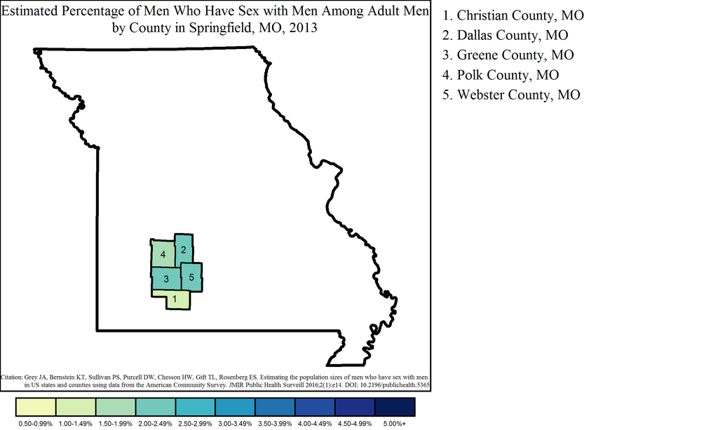

#### Columbia Metropolitan Statistical Area

The Columbia MSA had a population of 1,394 MSM, or 2.0% of all MSM in Missouri. Of the 62,471 adult men in Columbia, an estimated 2.2% were MSM.

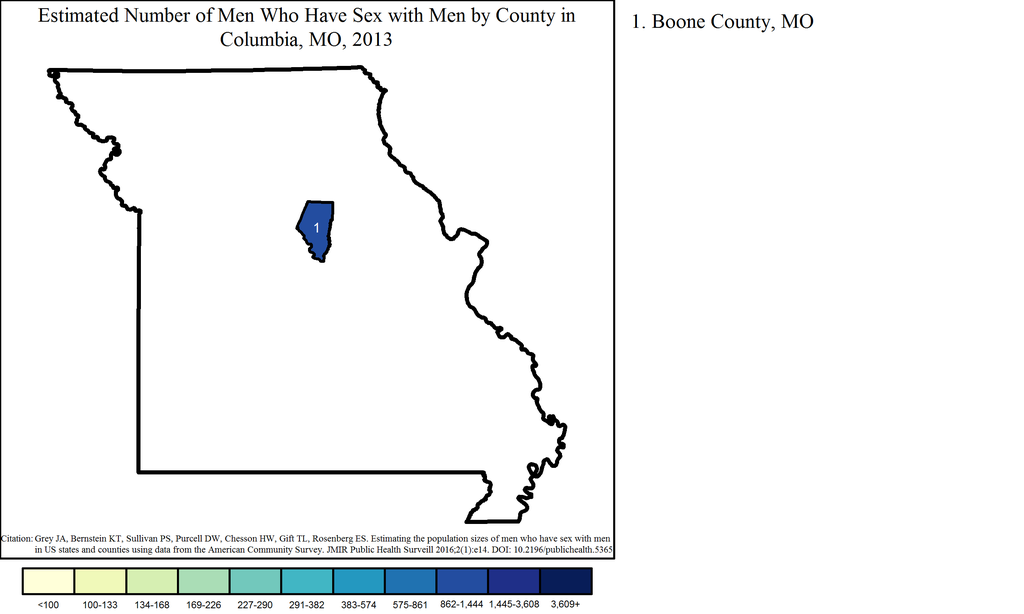

Note: Range cutpoints for the map are based on the distribution of MSM among all counties in the United States.

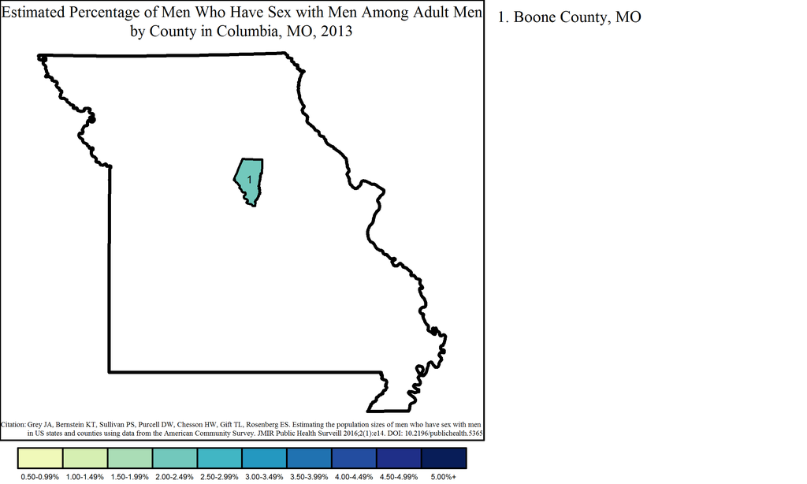

#### St. Joseph Metropolitan Statistical Area

The St. Joseph MSA overlaps two states: Kansas and Missouri. The Missouri portion of the MSA had 1,250 MSM, or 1.8% of all MSM in the state and 96.1% of the 1,301 MSM in the MSA. Of 47,325 adult men in the Missouri part of St. Joseph, 2.6% were MSM. This was equal to the overall percentage of MSM among adult men in the MSA, which was 2.6% of adult men (1,301 out of 50,439).

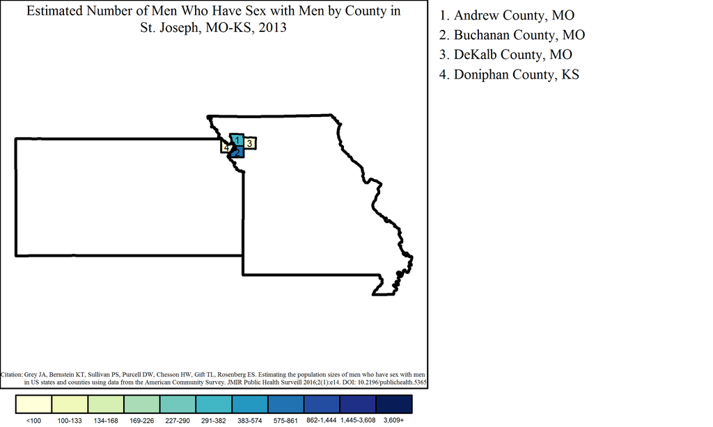

Note: Range cutpoints for the map are based on the distribution of MSM among all counties in the United States.

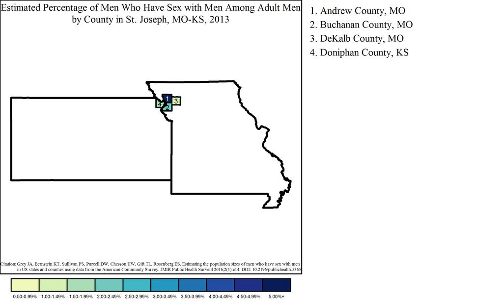

#### Joplin Metropolitan Statistical Area

The Joplin MSA had a population of 1,188 MSM, or 1.7% of all MSM in Missouri. Of the 63,144 adult men in Joplin, an estimated 1.9% were MSM.

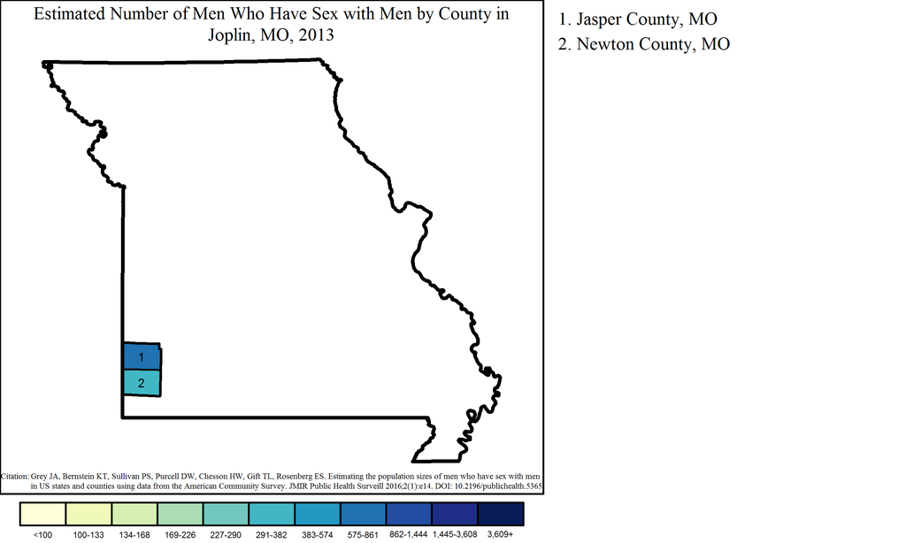

Note: Range cutpoints for the map are based on the distribution of MSM among all counties in the United States.

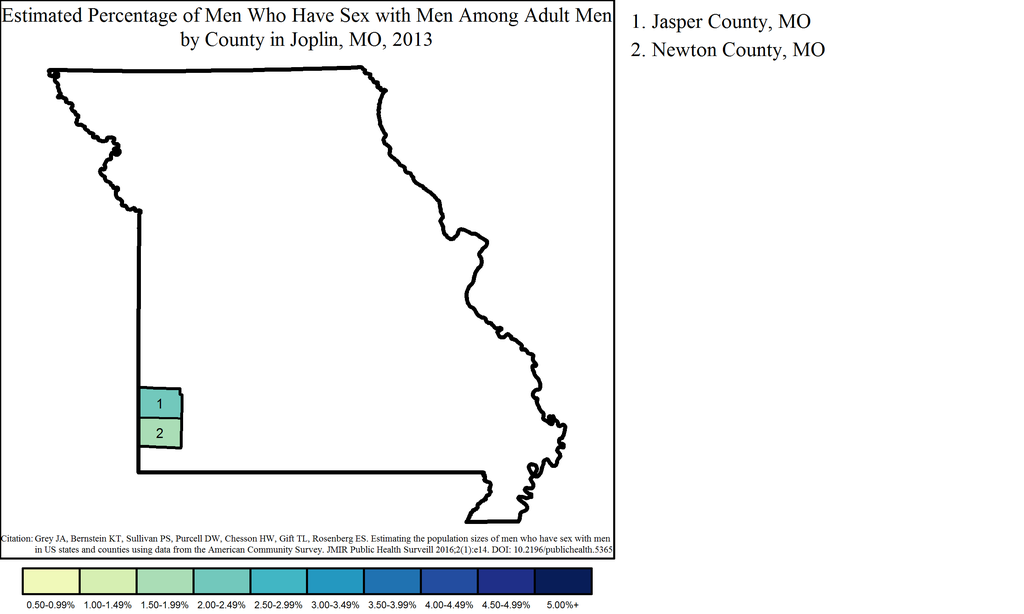

#### Jefferson City Metropolitan Statistical Area

The Jefferson City MSA had a population of 1,184 MSM, or 1.7% of all MSM in Missouri. Of the 58,759 adult men in Jefferson City, an estimated 2.0% were MSM.

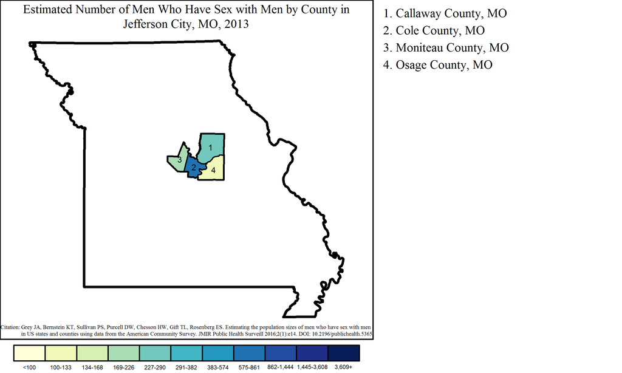

Note: Range cutpoints for the map are based on the distribution of MSM among all counties in the United States.

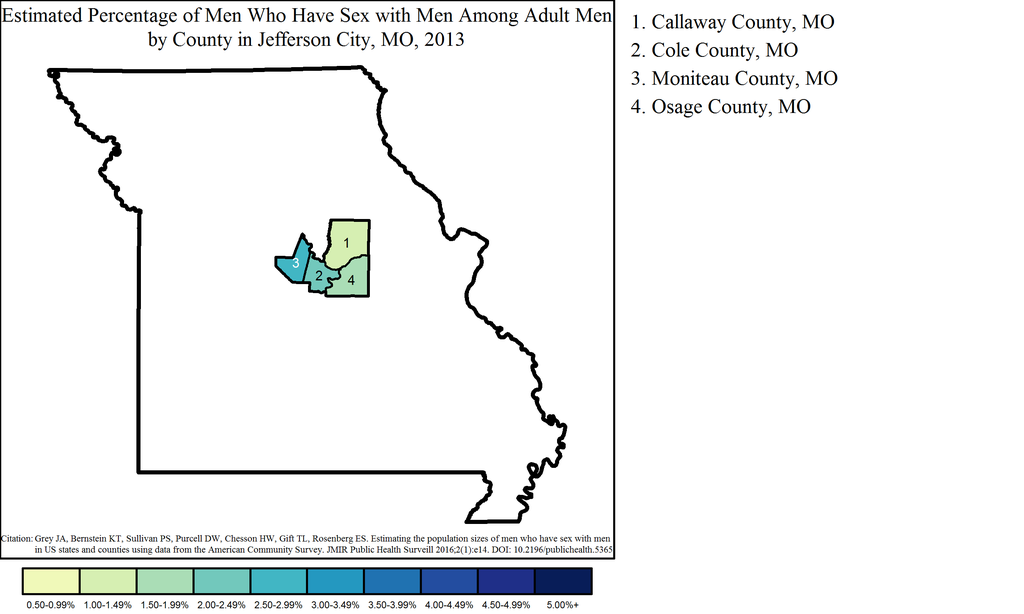

#### Cape Girardeau Metropolitan Statistical Area

The Cape Girardeau MSA overlaps two states: Illinois and Missouri. The Missouri portion of the MSA had 659 MSM, or 0.9% of all MSM in the state and 95.2% of the 692 MSM in the MSA. Of 33,067 adult men in the Missouri part of Cape Girardeau, 2.0% were MSM. This was greater than the overall percentage of MSM among adult men in the MSA, which was 1.9% of adult men (692 out of 36,166).

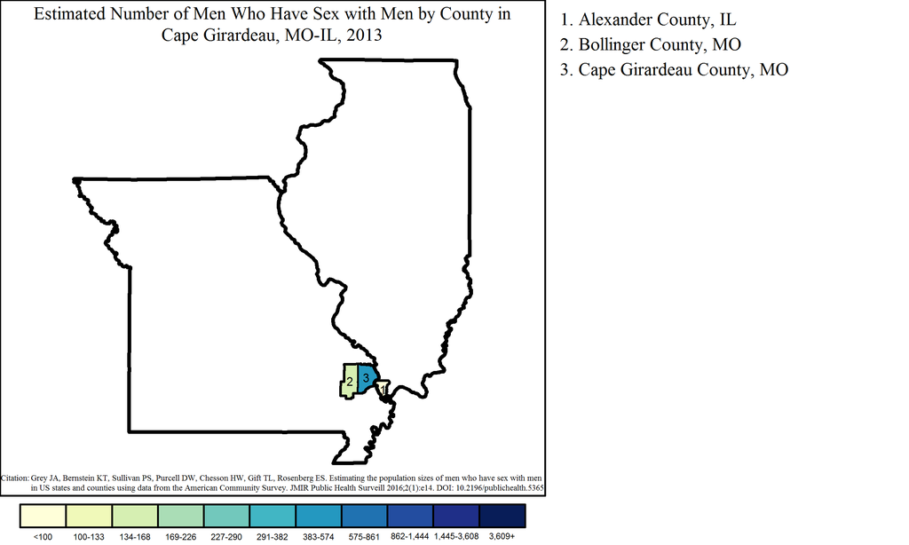

Note: Range cutpoints for the map are based on the distribution of MSM among all counties in the United States.

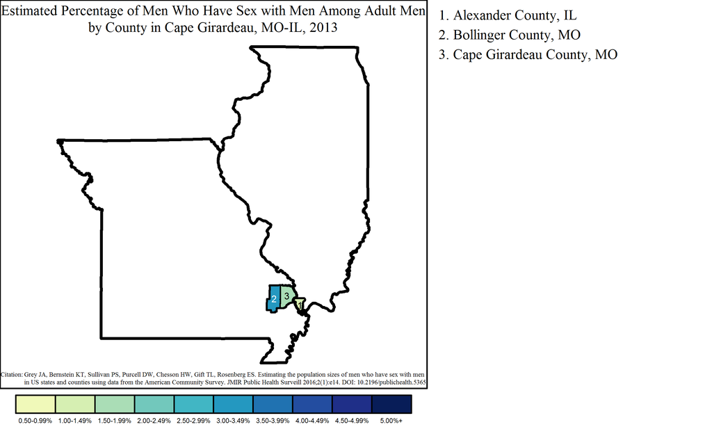

#### Fayetteville-Springdale-Rogers Metropolitan Statistical Area

The Fayetteville-Springdale-Rogers MSA overlaps two states: Arkansas and Missouri. The Missouri portion of the MSA had 90 MSM, or 0.1% of all MSM in the state and 3.0% of the 3,010 MSM in the MSA. Of 8,310 adult men in the Missouri part of Fayetteville-Springdale-Rogers, 1.1% were MSM. This was less than the overall percentage of MSM among adult men in the MSA, which was 1.8% of adult men (3,010 out of 171,768).

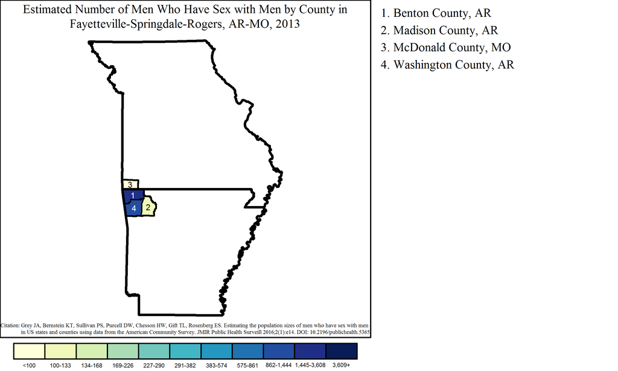

Note: Range cutpoints for the map are based on the distribution of MSM among all counties in the United States.

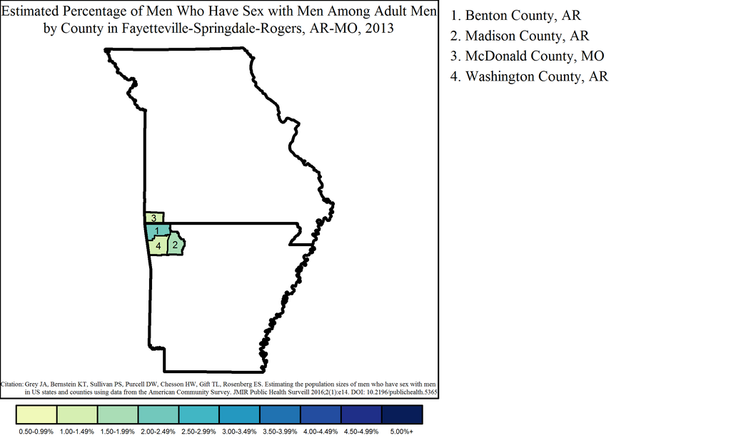